# TV Shows: Holiday Episodes Analysis

data from: rfordatascience/tidytuesday

Author

Federico Alegría

[figure not shown]

For {tidytuesdayR} `tt_load(2023, week = 51)`, we were given some data from the Internet Movie Database aka [IMDB](https://www.imdb.com/). According to [Wikipedia](https://en.wikipedia.org/wiki/IMDb), this database

> hosts information related to films, television series, podcasts, home videos, video games, and streaming content online; including cast, production crew and personal biographies, plot summaries, trivia, ratings, and fan and critical reviews.

Now, the main difference between the previous “[Holiday Movies](https://github.com/rfordatascience/tidytuesday/blob/master/data/2023/2023-12-12/readme.md)” dataset and this one is the cappability of contrasting a specific average from holiday related episodes with their broader average. You can check check out my previous data frolicking [here](https://github.com/federicoalegria/tidytuesday/tree/main/2023/50)!

### Fun Facts

- “The Nightmare Before Christmas” (1993) is the most voted holiday movie with 367,288 votes
- ’Bringing Back Christmas” (2023) is the movie with the highest average rating of 9.9
- There’s a Christmas movie about killer raccoons? 🦝💥

## Packages & Data

```r
pacman::p_load(
  easystats,
  ggforce,
  ggthemes,
  janitor,
  magrittr,
  patchwork,
  skimr,
  tidyquant,
  tidyverse
)

he <-
  readr::read_csv(
    'https://raw.githubusercontent.com/rfordatascience/tidytuesday/master/data/2023/2023-12-19/holiday_episodes.csv'
  ) |>
  janitor::clean_names()
```

### Quick Disclaimer

The two numeric variables containing average_rating and parent_average_rating got my attention right away. Nevertheless, the average rating can’t be treated as a good sample due to its non-random nature…

(╯°□°）╯︵ ┻━┻

## The Broad Picture

Despite that, we still can have some fun with it!

Typically, the independent variable gets plotted on the x-axis and the dependent variable on the y-axis. For this scenario, I recognised the average from the TV show or parent series as an independent variable. Logically, the holiday episode’s rating should behave according to its parent series.

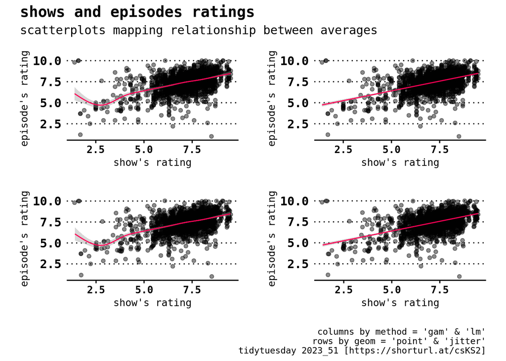

```r
# scatter plots for patchwork
p1 <-
  he |>
  ggplot(aes(x = parent_average_rating,
             y = average_rating)) +
  geom_point(alpha = 0.45) +
  geom_smooth(colour = '#ff0055',
              linewidth = 0.5,
              method = 'gam') +
  theme_wsj() +
  labs(x = "show's rating",
       y = "episode's rating") +
  theme(
    axis.text.x = element_text(family = 'Consolas', size = 10),
    axis.title = element_text(family = 'Consolas', size = 10),
    panel.background = element_rect(fill = 'transparent'),
    plot.background = element_rect(fill = 'transparent'),
    legend.background = element_rect(fill = 'transparent')
)

p2 <-
  he |>
  ggplot(aes(x = parent_average_rating,
             y = average_rating)) +
  geom_point(alpha = 0.45) +
  geom_smooth(colour = '#ff0055',
              linewidth = 0.5,
              method = 'lm') +
  theme_wsj() +
  labs(x = "show's rating",
       y = "episode's rating") +
  theme(
    axis.text.x = element_text(family = 'Consolas', size = 10),
    axis.title = element_text(family = 'Consolas', size = 10),
    panel.background = element_rect(fill = 'transparent'),
    plot.background = element_rect(fill = 'transparent'),
    legend.background = element_rect(fill = 'transparent')
)

p3 <-
  he |>
  ggplot(aes(x = parent_average_rating,
             y = average_rating)) +
  geom_jitter(alpha = 0.45) +
  geom_smooth(colour = '#ff0055',
              linewidth = 0.5,
              method = 'gam') +
  theme_wsj() +
  labs(x = "show's rating",
       y = "episode's rating") +
  theme(
    axis.text.x = element_text(family = 'Consolas', size = 10),
    axis.title = element_text(family = 'Consolas', size = 10),
    panel.background = element_rect(fill = 'transparent'),
    plot.background = element_rect(fill = 'transparent'),
    legend.background = element_rect(fill = 'transparent')
)

p4 <-
  he |>
  ggplot(aes(x = parent_average_rating,
             y = average_rating)) +
  geom_jitter(alpha = 0.45) +
  geom_smooth(colour = '#ff0055',
              linewidth = 0.5,
              method = 'lm') +
  theme_wsj() +
  labs(x = "show's rating",
       y = "episode's rating") +
  theme(
    axis.text.x = element_text(family = 'Consolas', size = 10),
    axis.title = element_text(family = 'Consolas', size = 10),
    panel.background = element_rect(fill = 'transparent'),
    plot.background = element_rect(fill = 'transparent'),
    legend.background = element_rect(fill = 'transparent')
)

# patchwork
(p1 + p2) / (p3 + p4) +
  plot_annotation(
    title = "shows and episodes ratings",
    subtitle = "scatterplots mapping relationship between averages",
    caption = "columns by method = 'gam' & 'lm'
    rows by geom = 'point' & 'jitter'
    tidytuesday 2023_51 [https://shorturl.at/csKS2]",
    theme = theme(plot.title = element_text(face = 'bold', size = 15),
                  plot.subtitle = element_text(face = 'plain', size = 12))
  ) &
  theme(text = element_text(family = 'Consolas')
)
```

Despite the somewhat linear relationship we can see, the data-mass feels a bit heavy don’t you think? Let’s breakdown this massive thing into smaller pieces, like the **top 9 genres**!

```r
# md table
he |>
  mutate(genres = str_replace(
    genres, ",(.*)", "")
  ) |>
  group_by(genres) |>
  summarise(n = n()) |>
  arrange(desc(n)) |>
  filter(n >= 55) |>
  filter(genres != "NA") |>
  knitr::kable(
)
```

| genres | n |
| --- | --- |
| Comedy | 1097 |
| Action | 229 |
| Animation | 210 |
| Adventure | 194 |
| Drama | 146 |
| Crime | 86 |
| Reality-TV | 68 |
| Documentary | 64 |
| Family | 55 |

Now let’s see how these genres behave:

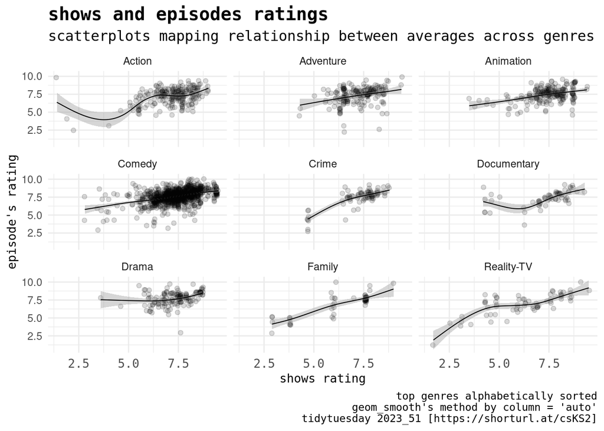

```r
# facet wrapped scatter plot
he |>
  mutate(genres = str_replace(genres, ",(.*)", "")) |>
  filter(
    genres %in% c(
      "Comedy",
      "Action",
      "Animation",
      "Adventure",
      "Drama",
      "Crime",
      "Reality-TV",
      "Documentary",
      "Family"
    )
  ) |>
  ggplot(aes(x = parent_average_rating,
             y = average_rating)) +
  geom_jitter(alpha = 0.15) +
  geom_smooth(colour = '#000000',
              linewidth = 0.35) +
  facet_wrap( ~ genres) +
  theme_minimal() +
  labs(
    title = "shows and episodes ratings",
    subtitle = "scatterplots mapping relationship between averages across genres",
    caption = "top genres alphabetically sorted
    geom_smooth's method by column = 'auto'
    tidytuesday 2023_51 [https://shorturl.at/csKS2]",
    x = "shows rating",
    y = "episode's rating") +
  theme(
    axis.text.x = element_text(family = 'Consolas', size = 10),
    axis.title = element_text(family = 'Consolas', size = 10),
    plot.title = element_text(face = 'bold', family = 'Consolas', size = 15),
    plot.subtitle = element_text(face = 'plain', family = 'Consolas', size = 12),
    plot.caption = element_text(face = 'plain', family = 'Consolas')
)
```

Interesting…

## Diving Deeper into Genres

Have you ever heard of [Hull Plots](https://ggforce.data-imaginist.com/reference/geom_mark_hull.html)? This cool-looking geom is part of the {ggforce} package, and helps getting a clear definition of how scattered our data-points are.

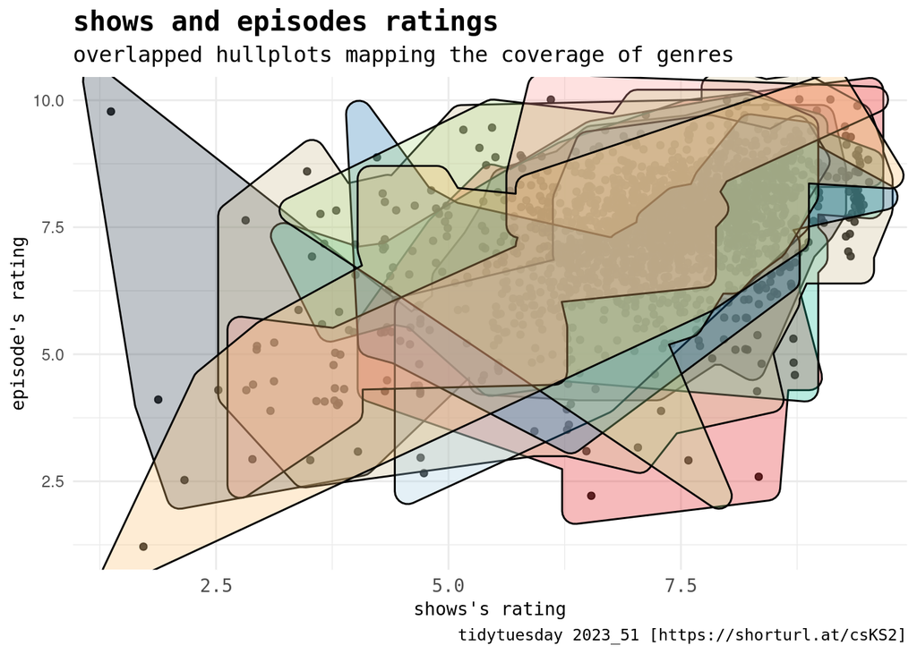

```r
# broad hull plot
he |>
  mutate(genres = str_replace(genres, ",(.*)", "")) |>
  filter(
    genres %in% c(
      "Comedy",
      "Action",
      "Animation",
      "Adventure",
      "Drama",
      "Crime",
      "Reality-TV",
      "Documentary",
      "Family"
    )
  ) |>
  ggplot(aes(x = parent_average_rating,
             y = average_rating)) +
  geom_jitter(alpha = 0.85) +
  geom_mark_hull(aes(fill = genres, label = genres),
                 concavity = 2.8) +
  theme_minimal() +
  scale_fill_tq() +
  labs(
    title = "shows and episodes ratings",
    subtitle = "overlapped hullplots mapping the coverage of genres",
    caption = "tidytuesday 2023_51 [https://shorturl.at/csKS2]",
    x = "shows's rating",
    y = "episode's rating") +
  theme(
    axis.text.x = element_text(family = 'Consolas', size = 10),
    axis.title = element_text(family = 'Consolas', size = 10),
    plot.title = element_text(face = 'bold', family = 'Consolas', size = 15),
    plot.subtitle = element_text(face = 'plain', family = 'Consolas', size = 12),
    plot.caption = element_text(face = 'plain', family = 'Consolas'),
    legend.position = 'none'
)
```

Jeez, it seems that genres are scattered all over the place! Let’s spread them a bit:

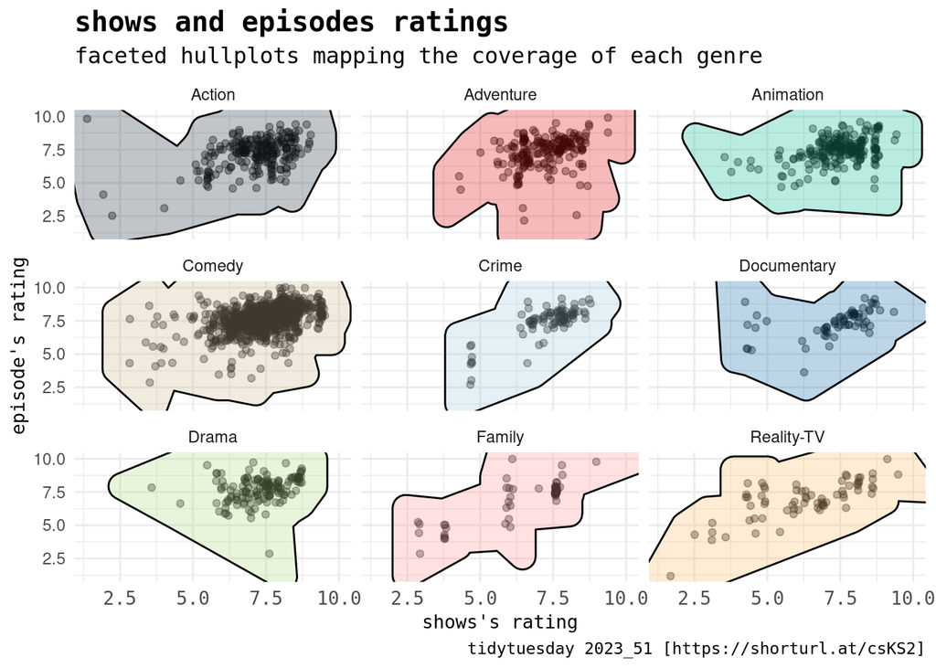

```r
# facet wrapped hull plot
he |>
  mutate(genres = str_replace(genres, ",(.*)", "")) |>
  filter(
    genres %in% c(
      "Comedy",
      "Action",
      "Animation",
      "Adventure",
      "Drama",
      "Crime",
      "Reality-TV",
      "Documentary",
      "Family"
    )
  ) |>
  ggplot(aes(x = parent_average_rating,
             y = average_rating)) +
  geom_jitter(alpha = 0.35) +
  geom_mark_hull(aes(fill = genres),
                 concavity = 2.8) +
  expand_limits(x = 10,
                y = 10) +
  theme_minimal() +
  scale_fill_tq() +
  labs(
    title = "shows and episodes ratings",
    subtitle = "faceted hullplots mapping the coverage of each genre",
    caption = "tidytuesday 2023_51 [https://shorturl.at/csKS2]",
    x = "shows's rating",
    y = "episode's rating") +
  theme(
    axis.text.x = element_text(family = 'Consolas', size = 10),
    axis.title = element_text(family = 'Consolas', size = 10),
    plot.title = element_text(face = 'bold', family = 'Consolas', size = 15),
    plot.subtitle = element_text(family = 'Consolas', size = 12),
    plot.caption = element_text(family = 'Consolas'),
    legend.position = 'none'
  ) +
  facet_wrap(~ genres
)
```

Now, let’s pick two of these for a better comparison!

### Comedy

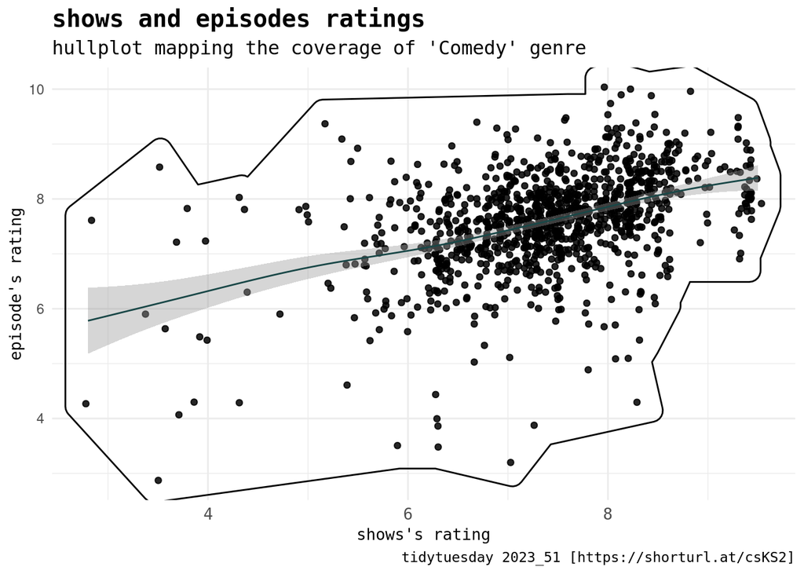

```r
# hull plot focused on "Comedy"
he |>
  mutate(genres = str_replace(genres, ",(.*)", "")) |>
  filter(
    genres %in% c(
      "Comedy"
    )
  ) |>
  ggplot(aes(x = parent_average_rating,
             y = average_rating)) +
  geom_jitter(alpha = 0.85) +
  geom_mark_hull(concavity = 2.8) +
  geom_smooth(colour = '#194747',
              linewidth = 0.5) +
  theme_minimal() +
  labs(
    title = "shows and episodes ratings",
    subtitle = "hullplot mapping the coverage of 'Comedy' genre",
    caption = "tidytuesday 2023_51 [https://shorturl.at/csKS2]",
    x = "shows's rating",
    y = "episode's rating") +
  theme(
    axis.text.x = element_text(family = 'Consolas', size = 10),
    axis.title = element_text(family = 'Consolas', size = 10),
    plot.title = element_text(face = 'bold', family = 'Consolas', size = 15),
    plot.subtitle = element_text(family = 'Consolas', size = 12),
    plot.caption = element_text(family = 'Consolas'),
    legend.position = 'none'
)
```

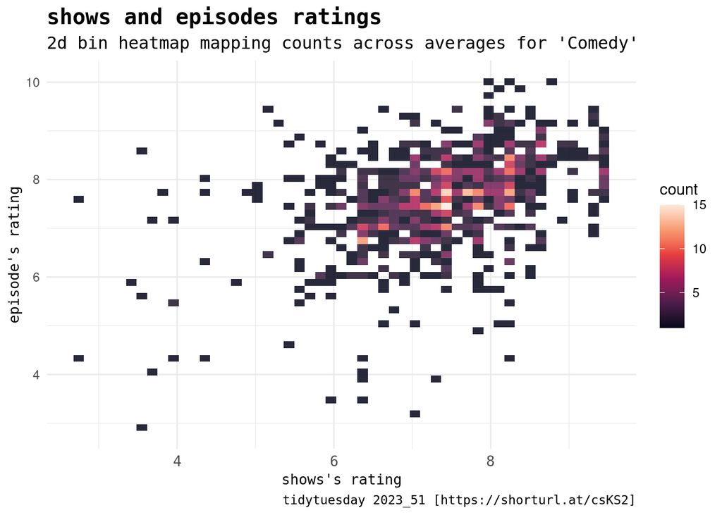

```r
# 2d bin counts heat map plot for "Comedy"
he |>
  mutate(genres = str_replace(genres, ",(.*)", "")) |>
  filter(genres %in% c("Comedy")) |>
  ggplot(aes(x = parent_average_rating,
             y = average_rating)) +
  geom_bin_2d(bins = 50, alpha = 0.85) +
  scale_fill_viridis_c(option = 'rocket') +
  theme_minimal() +
  labs(
    title = "shows and episodes ratings",
    subtitle = "2d bin heatmap mapping counts across averages for 'Comedy'",
    caption = "tidytuesday 2023_51 [https://shorturl.at/csKS2]",
    x = "shows's rating",
    y = "episode's rating") +
  theme(
    axis.text.x = element_text(family = 'Consolas', size = 10),
    axis.title = element_text(family = 'Consolas', size = 10),
    plot.title = element_text(face = 'bold', family = 'Consolas', size = 15),
    plot.subtitle = element_text(family = 'Consolas', size = 12),
    plot.caption = element_text(family = 'Consolas')
)
```

### Reality-TV

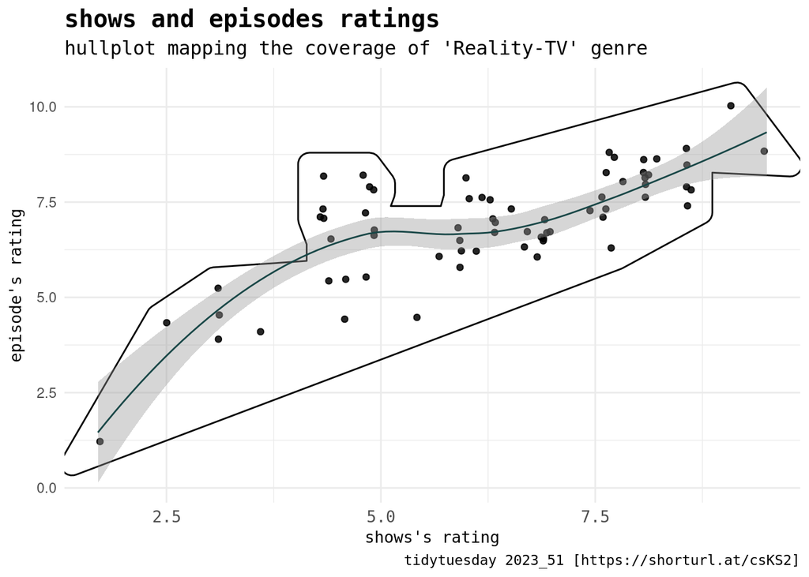

```r
# hull plot focused on "Reality-TV"
he |>
  mutate(genres = str_replace(genres, ",(.*)", "")) |>
  filter(
    genres %in% c(
      "Reality-TV"
    )
  ) |>
  ggplot(aes(x = parent_average_rating,
             y = average_rating)) +
  geom_jitter(alpha = 0.85) +
  geom_mark_hull(concavity = 2.8) +
  geom_smooth(colour = '#194747',
              linewidth = 0.5) +
  theme_minimal() +
  labs(
    title = "shows and episodes ratings",
    subtitle = "hullplot mapping the coverage of 'Reality-TV' genre",
    caption = "tidytuesday 2023_51 [https://shorturl.at/csKS2]",
    x = "shows's rating",
    y = "episode's rating") +
  theme(
    axis.text.x = element_text(family = 'Consolas', size = 10),
    axis.title = element_text(family = 'Consolas', size = 10),
    plot.title = element_text(face = 'bold', family = 'Consolas', size = 15),
    plot.subtitle = element_text(family = 'Consolas', size = 12),
    plot.caption = element_text(family = 'Consolas'),
    legend.position = 'none'
)
```

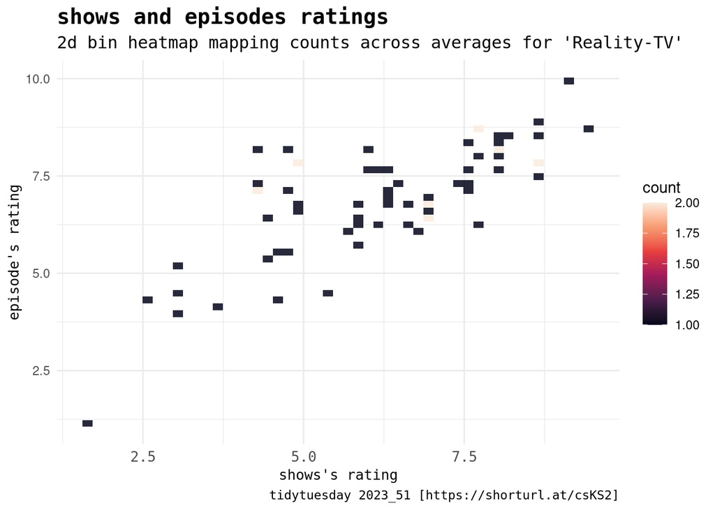

```r
# 2d bin counts heat map plot for "Reality-TV"
he |>
  mutate(genres = str_replace(genres, ",(.*)", "")) |>
  filter(genres %in% c("Reality-TV")) |>
  ggplot(aes(x = parent_average_rating,
             y = average_rating)) +
  geom_bin_2d(bins = 50, alpha = 0.85) +
  scale_fill_viridis_c(option = 'rocket') +
  theme_minimal() +
  labs(
    title = "shows and episodes ratings",
    subtitle = "2d bin heatmap mapping counts across averages for 'Reality-TV'",
    caption = "tidytuesday 2023_51 [https://shorturl.at/csKS2]",
    x = "shows's rating",
    y = "episode's rating") +
  theme(
    axis.text.x = element_text(family = 'Consolas', size = 10),
    axis.title = element_text(family = 'Consolas', size = 10),
    plot.title = element_text(face = 'bold', family = 'Consolas', size = 15),
    plot.subtitle = element_text(family = 'Consolas', size = 12),
    plot.caption = element_text(family = 'Consolas')
)
```

I picked **Comedy** and **Reality-TV** for the following reasons:

- they both appear to have a somewhat positive correlation
- they seem as pretty different genres
- their data-points are significantly different

However. the following comparisons won’t be performed between them but in-between, that’s the reason behind the disclaimer from above.

## Bring me that Comparison!

Perhaps the easiest and most simple way to compare two numeric variables is by computing their mean. However, outliers can potentially mess with this measurement so relying on the median could be a healthy call. Thanks to the wonders of the {ggplot}, we can see them both in the following notched box-plots:

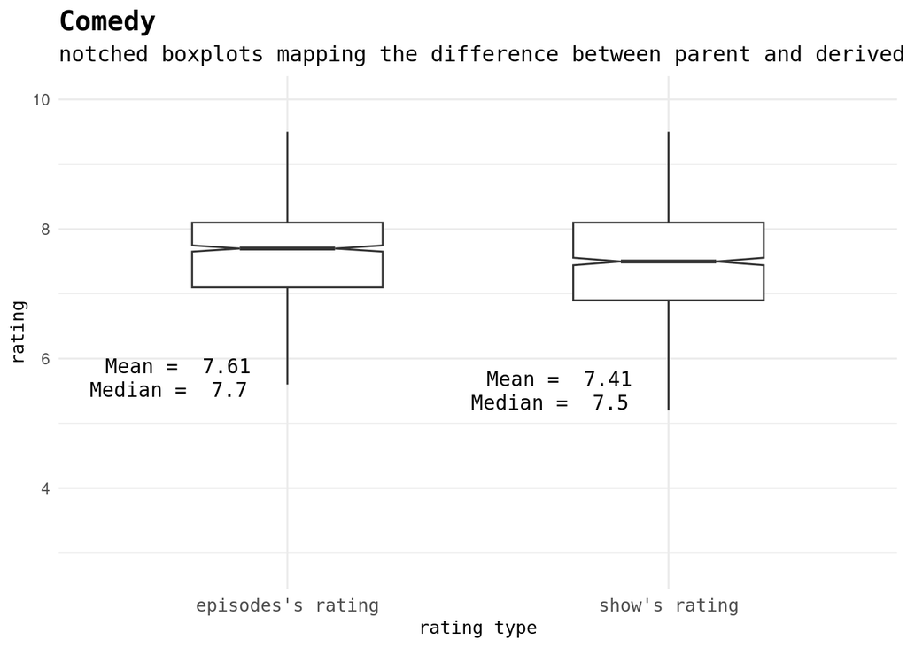

```r
# notched-box plot for "Comedy"
he |>
  mutate(genres = str_replace(genres, ",(.*)", ""))  |>
  filter(genres %in% c("Comedy")) |>
  pivot_longer(
    cols = c(parent_average_rating, average_rating),
    names_to = "rating_type",
    values_to = "rating_value"
  ) |>
  mutate(rating_type = case_when(
    rating_type == "parent_average_rating" ~ "show's rating",
    rating_type == "average_rating" ~ "episodes's rating",
    TRUE ~ rating_type
    )
  ) |>
  ggplot(aes(x = rating_type, y = rating_value, fill = rating_type)) +
  geom_boxplot(notch = TRUE,
               outlier.shape = NA,
               varwidth = TRUE,
               width = 0.5) +
  stat_summary(
    family = 'Consolas',
    fun = 'mean',
    geom = 'text',
    aes(label = paste("Mean = ", round(after_stat(y), 2))),
    position = position_dodge(width = 0.75),
    hjust = 1.25,
    vjust = 8
  ) +
  stat_summary(
    family = 'Consolas',
    fun = 'median',
    geom = 'text',
    aes(label = paste("Median = ", round(after_stat(y), 2))),
    position = position_dodge(width = 0.75),
    hjust = 1.25,
    vjust = 10
  ) +
  labs(
    title = "Comedy",
    subtitle = "notched boxplots mapping the difference between parent and derived ratings",
    x = "rating type",
    y = "rating") +
  scale_fill_manual(values = c("#ffffff", "#ffffff")) +
  theme_minimal() +
  theme(
    axis.text.x = element_text(family = 'Consolas', size = 10),
    axis.title = element_text(family = 'Consolas', size = 10),
    plot.title = element_text(face = 'bold', family = 'Consolas', size = 15),
    plot.subtitle = element_text(family = 'Consolas', size = 12),
    plot.caption = element_text(family = 'Consolas'),
    legend.position = 'none'
)
```

[figure not shown]

```r
# notched-box plot "Reality-TV"
he  |>
  mutate(genres = str_replace(genres, ",(.*)", "")) |>
  filter(genres %in% c("Reality-TV"))  |>
  pivot_longer(
    cols = c(parent_average_rating, average_rating),
    names_to = "rating_type",
    values_to = "rating_value"
  ) |>
  mutate(rating_type = case_when(
    rating_type == "parent_average_rating" ~ "show's rating",
    rating_type == "average_rating" ~ "episodes's rating",
    TRUE ~ rating_type
  )
  ) |>
  ggplot(aes(x = rating_type, y = rating_value, fill = rating_type)) +
  geom_boxplot(notch = TRUE,
               outlier.shape = NA,
               varwidth = TRUE,
               width = 0.5) +
  stat_summary(
    family = 'Consolas',
    fun = 'mean',
    geom = 'text',
    aes(label = paste("Mean = ", round(after_stat(y), 2))),
    position = position_dodge(width = 0.75),
    hjust = 2,
    vjust = 11
  ) +
  stat_summary(
    family = 'Consolas',
    fun = 'mean',
    geom = 'text',
    aes(label = paste("Median = ", round(after_stat(y), 2))),
    position = position_dodge(width = 0.75),
    hjust = 2,
    vjust = 13
  ) +
  labs(
    title = "Reality-TV",
    subtitle = "notched boxplots mapping the difference between parent and derived ratings",
    x = "rating type",
    y = "rating") +
  scale_fill_manual(values = c("#ffffff", "#ffffff")) +
  theme_minimal() +
  theme(
    axis.text.x = element_text(family = 'Consolas', size = 10),
    axis.title = element_text(family = 'Consolas', size = 10),
    plot.title = element_text(face = 'bold', family = 'Consolas', size = 15),
    plot.subtitle = element_text(family = 'Consolas', size = 12),
    plot.caption = element_text(family = 'Consolas'),
    legend.position = 'none'
)
```

Did you notice the `pivot_longer()` function? This was necessary for graphing these plots. Also important for you to know, notches offer a rough guide to the significance of the difference between medians. When these don’t overlap, we can interpret the visualisation as evidence of a statistically significant difference between the medians of the groups.

But we can’t just rely on visual information!

[figure not shown]

## Ye Olde Tests

First thing’s first, so we need to check for normality; for this,

```r
he |>
  mutate(genres = str_replace(genres, ",(.*)", "")) |>
  filter(genres %in% c("Comedy")) %$%
  ks.test(parent_average_rating,
          'pnorm',
          mean(parent_average_rating),
          sd(parent_average_rating)
)
```

```
    Asymptotic one-sample Kolmogorov-Smirnov test

data:  parent_average_rating
D = 0.069319, p-value = 5.278e-05
alternative hypothesis: two-sided
```

```r
he |>
  mutate(genres = str_replace(genres, ",(.*)", "")) |>
  filter(genres %in% c("Reality-TV")) %$%
  ks.test(parent_average_rating,
          'pnorm',
          mean(parent_average_rating),
          sd(parent_average_rating)
)
```

```
    Asymptotic one-sample Kolmogorov-Smirnov test

data:  parent_average_rating
D = 0.10101, p-value = 0.4916
alternative hypothesis: two-sided
```

༼ つ ◕_◕ ༽つ

Alright… But what does these results even mean?

The Kolmogorov-Smirnov test has a peculiar hypothesis scheme:

- H0: The sample comes from a normally distributed population
- H1: The sample does not come from a normally distributed population

In our case, we focused on the `parent_average_rating` for the reasons stated above.

## Correlation Tests

In a nutshell, correlation coefficients are statistical measures for assessing the strength and direction of a linear relationship between two variables; show and episode ratings for our case. Resulting coefficients will always range from -1 to 1. Here, an absolute value of “1” indicates a perfect degree of association and “0” means no linear relationship at all! The sign indicates the direction of the relationship; positive or negative. And as everything in inferential statistics, they come in parametric and non-parametric flavours.

### Spearman’s Rank Correlation Coefficient

```r
he |>
  mutate(genres = str_replace(genres, ",(.*)", "")) |>
  filter(genres %in% c("Comedy")) %$%
  cor.test(parent_average_rating,
           average_rating,
           method = 'spearman')
```

```
    Spearman's rank correlation rho

data:  parent_average_rating and average_rating
S = 124432456, p-value < 2.2e-16
alternative hypothesis: true rho is not equal to 0
sample estimates:
      rho
0.4344573
```

### Pearson’s product-moment correlation

```r
he |>
  mutate(genres = str_replace(genres, ",(.*)", "")) |>
  filter(genres %in% c("Reality-TV")) %$%
  cor.test(parent_average_rating,
           average_rating,
           method = 'pearson')
```

```
    Pearson's product-moment correlation

data:  parent_average_rating and average_rating
t = 8.9732, df = 66, p-value = 4.852e-13
alternative hypothesis: true correlation is not equal to 0
95 percent confidence interval:
 0.6108542 0.8325809
sample estimates:
      cor
0.7413123
```

**Murky Waters Ahead**